# Location, Cities, and Agglomeration

Module 1 · Student reader · ECON 463

Author

Jude Bayham

# 1 Opening question

## 1.1 Why does activity concentrate?

Imagine an economy in which every location has the same resources, every firm can produce efficiently at a tiny scale, and moving goods, people, and information costs nothing. In that economy, concentrating production in one place offers little obvious advantage. Real economies depart from all three conditions. Some places have productive land or access to waterways. Large establishments can spread fixed costs across more output. Firms can benefit from nearby suppliers, workers, and other firms. Moving across space also consumes resources. These differences make location an economic choice rather than a label on a map.

The question for this module is **why economic activity concentrates in particular places**. A useful answer identifies a decision maker, an alternative, and a mechanism. Saying that firms locate in a city because it is a business center merely restates the observation. Saying that a firm saves delivery costs by locating near its customers explains a possible choice. Saying that nearby producers support a specialized repair service identifies a different mechanism. Both mechanisms may operate in the same place, but they imply different responses to changes in transport costs or industrial composition.

Regional economics studies economic activity across places and the connections among them. Urban economics examines cities, including their formation and internal organization. The subjects overlap: a city purchases inputs from other regions, attracts commuters and migrants, and sells products elsewhere. A region need not be a city, and its economically relevant boundary need not match an administrative boundary. For now, treat a region as an area relevant to the question being asked. Module 3 will develop measurement and boundary choices in detail.

By the end of this module, you should be able to explain how natural advantages, transport costs, and scale economies affect location and city formation (**LO1**). You should also be able to distinguish supplier sharing, labor pooling, and knowledge spillovers, and explain how congestion and other costs limit concentration (**LO2**). The numerical work is deliberately small enough to solve by hand. The goal is to connect an economic argument to a calculation whose assumptions you can explain.

## 1.2 How to use this reader

No advance reading is expected. Use this reader during or after class; no software setup is needed. The sequence matches the lecture deck. Read an example’s setup, make a prediction, and then check the calculation. When your prediction is wrong, identify which cost or assumption you overlooked. After each example, ask: **What mechanism explains this result, and which assumption would change your conclusion?** That question is more useful than memorizing the preferred location in one particular table.

Two readings are required: Hoover and Giarratani (2020), Chapter 1, printed pp. 12–15, and Chapter 2, §§2.3–2.7, pp. 19–35, for regional framing, resource endowments, and location choice; and Brueckner (2011), Chapter 1, §§1.1–1.5, pp. 1–18, for scale economies, agglomeration, and their connections to transport and city formation. Use them as follow-up to class; no advance reading is assumed. The numerical examples in this reader are synthetic; they are not estimates for an actual firm or country. All amounts use illustrative **currency units (CU)**. Supplemental readings are identified where they add a distinct perspective. They are not an additional bundle of required chapters.

Before proceeding, check that you can distinguish total cost, marginal cost, and average cost; interpret a straight line’s intercept and slope; and solve an equation in one unknown. If one of these steps is unfamiliar, use the worked calculations as a refresher. Paper and, if useful, a calculator are sufficient.

# 2 Natural advantages and firm location

## 2.1 Natural advantages are only part of a location decision

A natural advantage is a location-specific feature such as a mineral deposit, agricultural suitability, or a navigable waterway. Such a feature can make an input cheaper or more productive. A manufacturing firm may nevertheless choose a location away from its raw materials if access to customers, labor, or infrastructure more than compensates. A low input price is one component of profitability, not a complete location rule.

It helps to distinguish natural advantages from advantages that depend on economic organization. A mineral deposit does not arise because neighboring firms are present. A specialized supplier network may arise because enough nearby customers make the supplier viable. A port combines physical geography with constructed infrastructure and institutions. Calling every existing advantage “natural” would obscure the question of how the advantage was created and whether it could change.

Transport costs also extend beyond the freight invoice. Time in transit can tie up inventory, uncertain delivery can interrupt production, and moving a fragile product can cause damage. A firm with perishable output may value reliability more than a small reduction in the quoted shipping rate. Our first example compresses these complications into transparent monetary entries. That simplification makes the arithmetic manageable while reminding us to ask what each entry represents.

For regional framing, see Hoover and Giarratani (2020), Chapter 1, printed pp. 12–15. For location factors and their connection to production, consult Chapter 2, especially §§2.3–2.7, pp. 19–35. These selections are required and provide the foundation for the opening location discussion.

## 2.2 Example 1: three possible plant locations

A firm must deliver the same product to the same customers, at the same quality and price, regardless of where it produces. Output is fixed at 1,000 units per period. It can select one of three sites: **Resource**, close to a raw-material source; **Junction**, with an intermediate combination of costs; or **Market**, close to customers. The labels describe possible advantages, not a complete map. The numbers below are costs per unit of finished output, including the inputs required to make that unit.

Table 1: Example 1: illustrative delivered costs, CU per unit of output.

| Site | Production | Inbound | Outbound | Total |
| --- | --- | --- | --- | --- |
| Resource | 40 | 2 | 18 | 60 |
| Junction | 43 | 6 | 8 | 57 |
| Market | 48 | 10 | 2 | 60 |

Production covers the plant’s nonfreight cost at the specified output, including any allocated fixed cost. Inbound shipping moves inputs to the plant; outbound shipping delivers the finished product to customers. The table already expresses both types of freight per unit of output. Do not multiply inbound freight again by the amount of raw material: doing so would count the input requirement twice.

Let $p_i$ be production cost, $a_i$ inbound shipping cost, and $b_i$ baseline outbound shipping cost for site $i$. Let $\tau$ multiply outbound freight rates. The delivered unit cost is

$$d_i(\tau)=p_i+a_i+\tau b_i.$$

At the baseline, $\tau=1$. Resource costs $40+2+18=60$ CU per unit. Junction costs $43+6+8=57$. Market costs $48+10+2=60$. **Junction is the least-cost site**, at 57 CU per unit. At 1,000 units, its total cost is 57,000 CU per period, a saving of 3,000 relative to either other site. Resource has the lowest production cost; Market has the lowest outbound cost. Neither has the lowest sum.

Cost minimization is sufficient here because revenue is identical across sites. If revenue is $R$, comparing profits $R-C_i$ gives the same ranking as comparing costs $C_i$. This equivalence fails if a site changes the price customers will pay, sales volume, product quality, or capacity. Then compare site-specific profits, $\pi_i=R_i-C_i$, and allow output to respond if the question requires it. A location with higher cost can still be more profitable if its revenue advantage is larger.

A second limitation concerns scale. We use a table evaluated at one output level; we cannot assume each cost remains unchanged when production doubles. Capacity constraints, fixed-cost spreading, or different input requirements can change the ranking. Always state both the choice being made and what is being held fixed. A model that answers “Which site supplies this order most cheaply?” does not automatically answer “How large should the firm become?”

## 2.3 A transport improvement can change the winner

Now suppose outbound freight rates fall by half at every site, so $\tau=0.5$. Production and inbound costs do not change. This is a deliberately narrow counterfactual: it is not a claim that a particular road project halves all shipping costs.

Table 2: Example 1: outbound freight rates halved, CU per unit. Outbound column shows baseline freight.

| Site | Production | Inbound | Base outbound | New total |
| --- | --- | --- | --- | --- |
| Resource | 40 | 2 | 18 | 51 |
| Junction | 43 | 6 | 8 | 53 |
| Market | 48 | 10 | 2 | 59 |

Resource now costs $42+0.5(18)=51$, Junction $49+0.5(8)=53$, and Market $58+0.5(2)=59$. Resource becomes the preferred site. All three benefit in absolute cost terms, but Resource benefits most because it initially paid the largest outbound freight bill. This separates an **absolute improvement** from a **relative advantage**. A location can become cheaper to use and still lose the competition for the plant.

To find the threshold, equate Resource and Junction:

$$42+18\tau=49+8\tau,
\qquad 10\tau=7,
\qquad \tau^*=0.7.$$

Below 0.7, Resource is cheaper than Junction. Above it, Junction is cheaper than Resource. At the threshold, both cost $54.6$ CU per unit. But a pairwise tie is not automatically a global optimum: the third site must also be checked. Market costs $58+2(0.7)=59.4$, so it is more expensive at this threshold. Resource and Junction genuinely tie for the least cost.

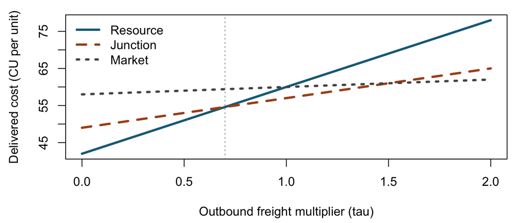

Figure 1: Example 1: the preferred site lies on the lower envelope of the three delivered-cost lines.

Each line’s intercept is production plus inbound cost, while its slope is baseline outbound cost. Resource has a low intercept and a steep slope. Market has a high intercept and a shallow slope. Junction and Market tie when $49+8\tau=58+2\tau$, giving $\tau=1.5$. Thus, for nonnegative freight multipliers, Resource wins below 0.7, Junction between 0.7 and 1.5, and Market above 1.5, with ties at the endpoints. The Resource–Market intersection at 1 is not a change in the winner: Junction is cheaper than both there.

## 2.4 Interpretation and self-check

**Question.** At $\tau=0.8$, which site wins, and why is a claim that “lower transport costs always favor the market location” incorrect?

**Worked answer.** Resource costs $56.4$, Junction $55.4$, and Market $59.6$. Junction remains cheapest. Relative to the baseline, Resource gains more from the freight reduction, but the reduction is not large enough to cross the 0.7 threshold. Lower delivery costs can make it economical to serve customers from farther away. In other circumstances, cheaper inbound freight may favor a market site. The direction depends on which costs change and how much each site uses the affected transport service.

Brueckner’s §1.4 discusses source-oriented and market-oriented production using transport costs and the relationship between input and output weight. Our table generalizes the accounting by including different production costs. A weight-losing process may favor proximity to the raw-material source, while a process using locally available inputs to add bulk may favor customers. These are conditional tendencies, not universal location laws. Multiple inputs, markets, transport modes, and production-cost differences can overturn a simple weight comparison.

## 2.5 Shipping charges and economies of distance

A longer shipment can cost more in total while costing less per mile. Let $S(k)=a+bk$ be the charge to ship one ton a distance of $k>0$ miles. The terminal charge $a$ covers loading and handling; $b$ is the additional charge per ton-mile. Then $S(k)/k=a/k+b$ is the average charge per ton-mile. The fixed terminal charge is spread over a longer distance.

For illustrative values $a=20$ CU per ton and $b=2$ CU per ton-mile, a 10-mile trip costs 40 CU per ton, or 4 CU per ton-mile. A 100-mile trip costs 220 CU per ton, or 2.2 CU per ton-mile. Total shipping expenditure rises, even though the average charge per mile falls. At zero distance no shipment is needed; do not interpret $a$ as a charge for not shipping.

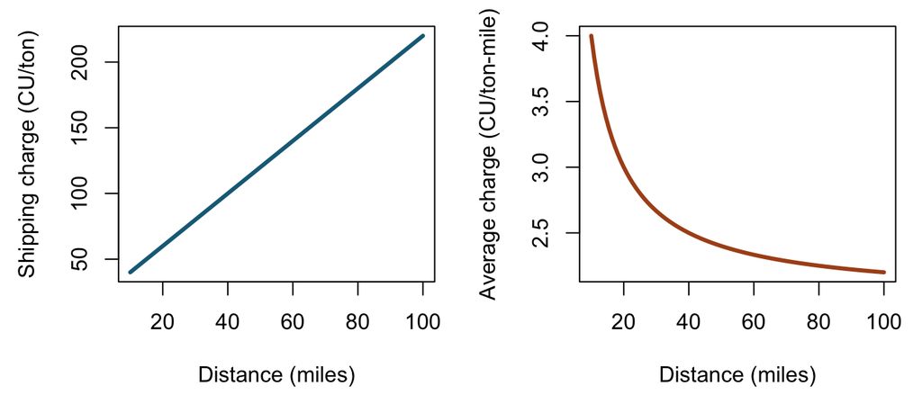

Figure 2: Illustrative shipping charges: higher charge per ton, lower average charge per ton-mile as distance increases.

In a graph of $S(k)$ against distance, the origin ray has slope $S(k)/k$, while the shipping line itself has slope $b$. Confusing these slopes confuses average with marginal cost. This distinction parallels the average-product rays in the scale-economy figure later in the reader. Brueckner Figure 1.4 develops this point.

Consider a simple route: **raw-material source → plant → customer market**. A refinery that discards material can avoid hauling discarded weight by processing near the source. A beverage producer that adds locally available water may save freight by locating near consumers. These stories motivate source-oriented and market-oriented production, but weight alone does not settle the decision. Shipping rates, product bulk, handling, alternative inputs, and the shape of distance costs matter.

Brueckner’s simplified continuous-route model combines economies of distance with input/output shipping differences to obtain an endpoint solution. Our three-site table does not impose those freight curves and allows production cost to differ by site. Junction can therefore win without contradicting that model. Do not apply the textbook’s endpoint conclusion to a different set of assumptions. A midway plant may be attractive with other freight technologies, multiple sources or markets, or site-specific production advantages.

# 3 Scale economies and city formation

## 3.1 Scale economies: start with the work

Imagine an island with 100 basket makers and reeds available as needed. In a one-person workshop, the same person gathers reeds, prepares them, weaves, and packs the finished baskets. In a larger factory, workers can specialize in individual tasks. Less time switching tasks and greater practice at each task can raise output per worker. This is an internal scale economy: the source of the gain is the organization of work within the establishment, not a change in neighboring firms.

Before calculating, predict whether dividing the workers among many workshops or bringing them together would produce more baskets. Our answer depends on the assumed technology. We are not claiming that a larger organization is always better. Coordination problems could eventually offset specialization, and a different technology might offer little benefit from working together.

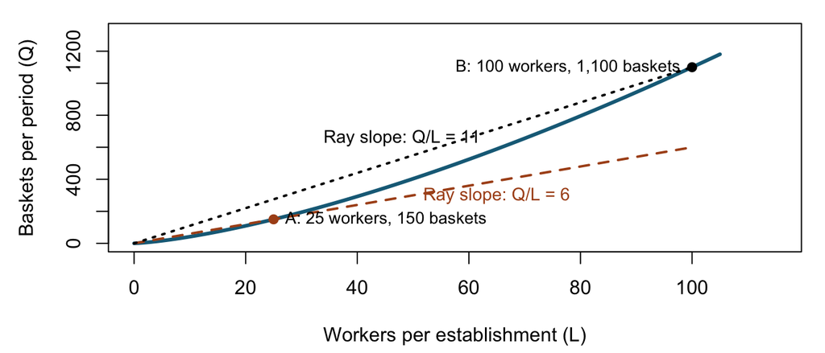

Figure 3: Illustrative basket production: the steeper ray from the origin indicates greater output per worker at B.

The horizontal axis measures workers per establishment, $L$, and the vertical axis measures baskets per period, $Q$. At A, $Q/L=150/25=6$ baskets per worker per period. At B, $Q/L=1{,}100/100=11$. A larger factory produces more in total, but that alone would not demonstrate greater efficiency. The important observation is that output grows more than proportionately to workers over this comparison.

The slope of a line from the origin to a point is average product, $Q/L$. It is not marginal product: the latter describes the extra output from another worker and corresponds to the tangent slope. In this illustration, other inputs such as reeds are available as needed. Do not interpret the figure as a general claim that adding workers with every other input fixed must increase output per worker.

Now compare two ways of organizing the same 100 workers. All values are illustrative and use the same technology as the figure; the one-worker workshop produces two baskets per period.

Table 3: Same total workforce, different organization. Output is baskets per period.

| Arrangement | Plants | Workers/plant | Baskets/worker | Total baskets |
| --- | --- | --- | --- | --- |
| 100 workshops | 100 | 1 | 2 | 200 |
| One factory | 1 | 100 | 11 | 1100 |

Total output equals the number of plants multiplied by workers per plant and output per worker. Separate workshops yield $100\times1\times2=200$ baskets; the single factory yields $1\times100\times11=1{,}100$. Both employ 100 workers. The physical-output gain follows from the assumed specialization advantage. Whether all additional baskets can be sold profitably would require demand and price information.

This comparison holds workers fixed and compares output. The next example instead holds the required order fixed and compares costs. These are two different ways to illustrate internal scale economies, not two representations of an identical technology. Brueckner §1.2 supplies the story and graphical reasoning; our numerical values are synthetic.

## 3.2 From choosing a site to choosing the number of plants

Example 1 held the number of plants fixed. Example 2 asks whether production should occur in one large plant or two smaller plants. These questions are related but distinct. A firm can select the best site for a given plant while still choosing the wrong number of plants overall. Regional concentration depends on both decisions: where establishments locate and how much employment or output each establishment contains.

Suppose a plant has cost $C(Q)=F+cQ$ for positive output, where $F$ is its avoidable fixed operating cost per period and $c$ is constant marginal production cost. Average production cost is

$$AC(Q)=\frac{F}{Q}+c.$$

As output increases, the fixed cost is spread across more units. With a positive fixed cost, doubling output halves the fixed-cost contribution per unit; the variable cost per unit remains $c$. This is an internal scale economy: it operates within the establishment. No neighboring firm is needed to generate it. Here the fixed cost is avoidable when deciding whether to operate a plant. A sunk cost that cannot be recovered should not be treated as an avoidable saving in the same decision.

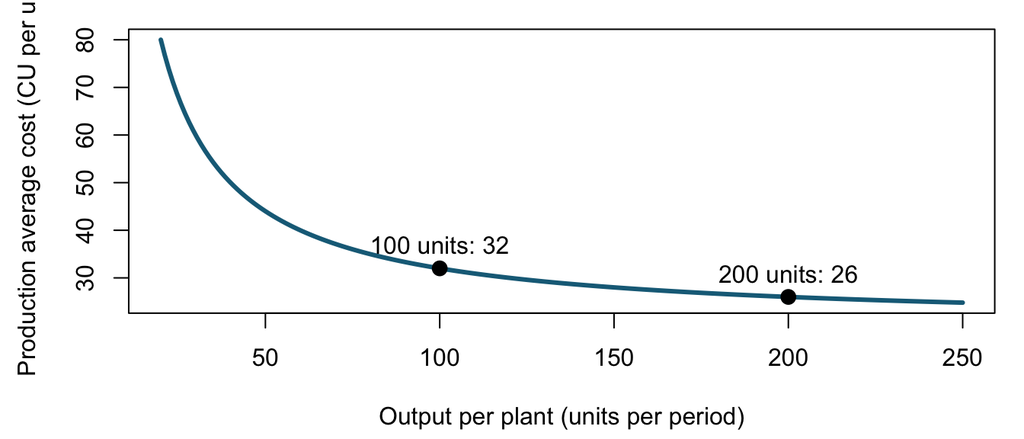

Figure 4: Example 2: fixed-cost spreading lowers average production cost as plant output increases. Shipping costs are excluded here.

This technology simplifies the benefits of specialization and indivisible equipment into one fixed cost. Real scale economies can arise because larger operations support specialized jobs, machinery, or management. They can also eventually be offset by coordination costs. We do not need to assume that average cost falls forever to understand why a larger plant can be cheaper over a relevant range. For the conceptual foundation, read Brueckner (2011), §1.2; for the interaction with transport, read §1.5, printed pp. 16–18.

## 3.3 Example 2: one plant or two?

There are two identical markets, each demanding 100 units per period. Each plant costs $F=1{,}200$ CU per period to operate, plus $c=20$ CU per unit produced. A firm can put one plant in each market, or serve both markets from a single plant in either market. Local delivery costs are normalized to zero. Shipping to the other market costs $t=4$ CU per unit. Input availability, product quality, and total revenue are identical across the alternatives; there are no capacity limits.

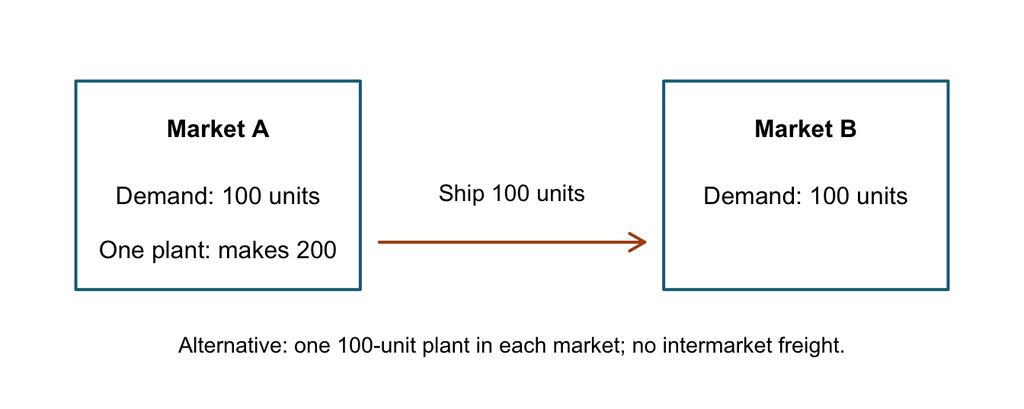

Figure 5: One plant serves both markets; only the remote market’s 100 units require intermarket shipping.

**Stage 1: production alone.** Temporarily set intermarket freight to zero. One plant pays 1,200 CU in fixed cost and $20\times200=4{,}000$ in variable cost, for 5,200 CU. Two plants pay $2\times1{,}200=2{,}400$ in fixed costs and the same 4,000 in variable cost, for 6,400 CU. The production saving from centralization is exactly one avoidable fixed cost: 1,200 CU per period.

**Stage 2: add shipping.** Restore $t=4$ CU per unit shipped. Two dispersed plants each serve 100 local units and incur no intermarket freight. One centralized plant serves 100 local units and ships the other 100, adding $4\times100=400$ CU. The spatial diagram tells us which quantity belongs in the freight bill.

Translate that accounting into notation, where $q=100$ is demand in each market:

$$C_D=2F+2cq=2(1{,}200)+20(200)=6{,}400,$$

$$C_C=F+2cq+tq=1{,}200+20(200)+4(100)=5{,}600.$$

Centralization saves 800 CU per period. Its production saving is one fixed cost, 1,200 CU; its additional shipping bill is 400 CU. Average delivered cost is $5{,}600/200=28$ CU under centralization and $6{,}400/200=32$ under dispersion. Notice that centralized *production* average cost is 26, but centralized *delivered* average cost is 28. Confusing these quantities would exaggerate the advantage of centralization.

## 3.4 Deriving and interpreting the threshold

First ask what freight bill would use up the 1,200-CU production saving. With 100 units shipped, a rate of 12 CU per unit does so. Now derive that result by subtracting the two cost expressions:

$$C_C-C_D=tq-F.$$

Centralization is cheaper when $tq<F$, dispersion is cheaper when $tq>F$, and the firm is indifferent when

$$t^*=\frac{F}{q}=\frac{1{,}200}{100}=12
\quad\text{CU per unit shipped}.$$

At $t=12$, both arrangements cost 6,400 CU. At $t=16$, centralization costs 6,800 CU, so dispersion is cheaper by 400 CU. The threshold compares a fixed-cost saving measured per period with a freight bill measured per period. Equating the fixed cost directly to a shipping rate without multiplying by the shipped quantity would mix units and produce an incorrect result.

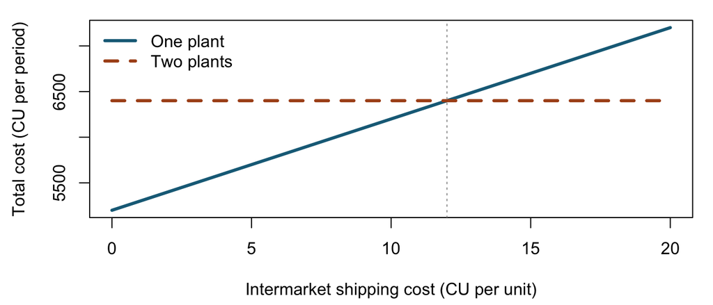

Figure 6: Example 2: centralized production is cheaper below an intermarket shipping rate of 12 CU per unit.

If demand per market doubles while the fixed cost stays unchanged, the threshold falls to 6. More units must be shipped under centralization, while the avoided fixed cost remains 1,200. At a shipping rate of 4, centralization still wins, but by only 400 CU. This does not mean larger markets always cause dispersion. It is the conclusion of this particular fixed-cost technology and two-market comparison. If larger output unlocks additional production efficiencies, or if market sizes differ, the calculation changes.

## 3.5 What does this tell us about cities?

A large plant concentrates jobs at one location. If commuting is costly, some workers will prefer to live nearby. Demand for housing and local services can then encourage a settlement around employment. This supplies one mechanism linking production scale to city formation: a company town can grow around a large employer. It does not establish a complete equilibrium city size: we have not modeled land, wages, commuting, household preferences, or housing supply.

It also does not explain why many independent firms locate together. The fixed-cost saving in Example 2 belongs to one firm’s plant organization. A cluster of separate firms may require a different argument involving shared suppliers, workers, or information. Keep the establishment-level mechanism separate from the neighborhood-level mechanism, even when both contribute to the same city’s development.

# 4 Guided practice and synthesis

## 4.1 Your turn: should the firm still centralize?

Keep demand at 100 units per market and variable production cost at 20 CU per unit. Now the fixed cost is 600 CU per plant and intermarket freight is 8 CU per unit. Predict which arrangement wins before calculating. Work by hand, then compare your reasoning with a neighbor. No code or software setup is required.

**Worked answer.** One plant costs $600+20(200)+8(100)=5{,}400$ CU per period. Two plants cost $2(600)+20(200)=5{,}200$. Dispersion wins by 200. The avoided fixed cost is only 600 while the additional freight bill is 800. The threshold is $F/q=600/100=6$ CU per unit shipped, below the actual rate of 8.

Two assumptions changed from the baseline: fixed cost fell and shipping became more expensive. Each favors dispersion. To isolate their separate contributions, change one at a time: with $F=600$ and the old $t=4$, centralization still saves 200; with the old $F=1{,}200$ and $t=8$, it saves 400. Neither separate change reverses the original decision, but together they do. This illustrates why you should identify all changes before attributing a result to one mechanism.

## 4.2 Practice with revenue and technology

**Practice A: revenue differs.** Return to the baseline location table. Suppose Market can earn an additional 5 CU of revenue per unit because it offers faster service, with output and all listed costs unchanged. Which site maximizes profit? Compare with Junction so you do not need to invent a baseline selling price.

**Worked answer.** Market costs 3 CU more per unit but earns 5 CU more revenue. Its profit is therefore 2 CU higher per unit, or 2,000 CU higher per period. The original cost ranking remains correct, but it no longer determines the profit ranking. If faster service also changes demand, revise quantities and costs as well.

**Practice B: change market size.** In Example 2, double demand to 200 units per market while keeping $F=1{,}200$, $c=20$, and $t=4$. Predict whether the benefit of centralization grows, then calculate both totals.

**Worked answer.** One plant costs $1{,}200+20(400)+4(200)=10{,}000$ CU. Two plants cost $2(1{,}200)+20(400)=10{,}400$. Centralization saves 400 rather than 800 because remote shipments double while the avoided fixed cost stays unchanged. Total demand is 400, not 200. This conclusion depends on the fixed-cost technology; it does not establish that bigger markets always favor dispersion.

For each answer, identify the preferred alternative, explain the mechanism, and name an assumption that could reverse the conclusion. A statement that one plant “is more efficient” leaves the relevant saving unstated. Explain whether you mean lower production cost or lower delivered cost, and distinguish either from higher profit.

# 5 Agglomeration mechanisms

## 5.1 External to the firm, connected to nearby activity

An agglomeration economy is an advantage associated with nearby economic activity that is external to the individual establishment’s own scale. To diagnose one, ask what would happen to the firm if neighboring activity changed while the firm’s own production scale stayed fixed. A larger internal production run is not, by itself, agglomeration. A repair specialist becoming available because many local manufacturers jointly provide enough demand can be.

Brueckner distinguishes **pecuniary effects**, operating through prices or costs of purchased inputs, from **technological effects** that change productivity. Cheaper recruitment or testing services can reduce the cost of obtaining an input; a better worker-job match can increase what the input produces. These channels answer a different question from the labels suppliers, labor, and knowledge: one describes how the benefit enters the firm’s decision, the other identifies its source. Our classification emphasizes three mechanisms: supplier sharing, labor pooling and matching, and knowledge spillovers. They overlap, but naming them separately helps formulate observable predictions. See Brueckner (2011), §1.3, and the supplemental discussion in Hoover and Giarratani (2020), §§5.2–5.4, printed pp. 84–96. The latter also discusses market attraction and the distinction between specialized clusters and urbanization.

## 5.2 Example 3: diagnosing a cluster

Imagine a cluster of independent precision-component firms. Each is small, and none could cheaply provide every specialized service internally. Consider three explanations for why they choose nearby locations. These are hypothetical mechanisms, not claims that we have measured their importance in a particular industry.

**Shared suppliers.** A specialist testing laboratory faces a substantial fixed cost for equipment and expertise. One customer alone cannot support frequent service at a reasonable price, but many nearby customers can. Each manufacturer can purchase testing without owning a full laboratory. A larger market may also sustain competing suppliers that offer lower prices. Availability of a service and competition over its price are distinct possible advantages. The specialist may itself exploit internal scale economies; the resulting availability of testing is an external advantage for its customers. Proximity matters if moving samples, coordinating tests, or correcting faults is costly. If samples can be shipped cheaply and turnaround time is irrelevant, the service might support geographically dispersed customers instead.

**Labor pooling and matching.** A concentration of employers attracts workers with specialized skills; a concentration of workers makes hiring easier for employers. A worker may accept specialized training more readily when several potential employers are available. A firm may fill a vacancy faster or find a better match. These benefits do not require lower wages: greater productivity and stronger competition for workers can raise wages. Compare labor cost per unit of effective output, not the wage alone.

Digital recruitment offers a useful counterfactual. Online vacancy information and interviews may reduce search and travel expenses, weakening one reason to locate nearby. They need not eliminate local skill matching, face-to-face coordination, or workers’ ability to change employers without moving home. The net effect on clustering is not determined by the existence of a digital tool alone.

**Classification check.** A deeper labor market cuts recruitment spending and helps the same-sized firm find workers whose skills better fit its tasks. Is this pecuniary or technological? **Worked answer:** both channels may operate: lower hiring costs and higher productivity from the resulting matches. Do not force every mechanism into a single exclusive category. The reading also describes possible training and effort responses, including comparisons with peers; these are hypotheses about behavior, not automatic consequences of density.

Pooling can also reduce exposure to an individual firm’s demand fluctuations. When one employer contracts while another expands, workers may move without relocating their households. That insurance mechanism weakens if all local employers experience the same shock at the same time. A specialized cluster may therefore support excellent matching in normal conditions while remaining vulnerable to an industry-wide downturn. Whether diversity helps depends partly on how shocks are correlated across activities.

**Knowledge spillovers.** Nearby workers and firms may learn from each other’s experience through professional interaction, employee movement, or observation. A production improvement developed in one firm may raise another firm’s productivity without full compensation to the originator. That uncompensated component is what makes the effect a spillover. Buying a consultant’s advice is a market transaction, even if it also transmits knowledge. Geographic proximity is useful when some knowledge is difficult to codify or exchange at a distance, but proximity alone does not guarantee learning.

## 5.3 Turn explanations into evidence questions

For the testing-laboratory mechanism, ask whether specialized services are available, whether local firms actually purchase them, and whether delivery times or costs differ from comparable isolated firms. For matching, examine vacancy duration, worker transitions, skill composition, and output per worker. For learning, ask what knowledge moved, between whom, and whether productivity changed beyond what purchased inputs or worker quality would predict. These questions move beyond simply counting firms in a cluster.

An observed association between density and productivity can reflect several processes. Productive firms may choose dense locations; high-skill workers may sort into those firms; both may be attracted by a port or university. A convincing causal claim requires a comparison that separates the proposed spillover from these alternatives. Module 1 introduces the interpretation problem without requiring a full econometric design. Glaeser and Gottlieb (2009), §3, printed pp. 999–1015, is optional advanced background on competing agglomeration explanations and their evidence.

**Self-check.** A firm’s average cost falls after it doubles production, but its neighbors do not change. Is this evidence of agglomeration? **Worked answer:** not from the information supplied. Fixed-cost spreading or internal specialization could explain the result. Conversely, if the firm maintains its output but gains access to a new local specialist serving many firms, supplier sharing is a plausible mechanism. Further evidence would still be needed to attribute the cost change to that service.

# 6 Limits and competing explanations

## 6.1 Why concentration does not grow without limit

The same concentration that improves access to workers and suppliers can intensify competition for land, road space, and environmental capacity. Longer commutes consume time; unreliable deliveries disrupt production; expensive space raises operating costs. Pollution and noise can reduce household well-being even when they do not appear fully in the firm’s accounts. The relevant comparison is the additional benefit and additional cost of locating in, or expanding, a cluster.

A simple private calculation illustrates the logic. Suppose an otherwise comparable cluster location provides 6 CU per unit of supplier savings and 4 CU of matching benefits, but adds 5 CU of occupancy cost and 3 CU of congestion cost. The firm’s net advantage is $6+4-5-3=2$ CU per unit. An additional congestion cost of 3 would reverse the ranking. These assumed amounts are a transparent accounting exercise, not estimates of an optimal city size. They also hold the effects on other firms and residents outside the calculation.

Private profitability is not identical to social welfare. A higher rent is a cost to a tenant and income to a landowner; some rent changes reflect the scarcity value of space rather than a direct loss of resources. Extra time wasted in congestion is a resource cost, while pollution can harm people outside the transaction. A policy assessment must distinguish transfers, real resource costs, and external effects. We will return to that distinction when interpreting regional policies later in the course.

## 6.2 Specialization versus diversity

A specialized cluster can support highly tailored suppliers and close worker matches within one industry. These are often called **localization economies**. A diverse city can support services, infrastructure, and ideas useful across industries; advantages associated with the broader urban scale and diversity are often called **urbanization economies**. Diversity may also reduce exposure to a single industry’s decline, although common shocks can still affect many sectors together.

Neither pattern is always superior. Precision manufacturing may benefit from a deep, narrow skill base, while a new business service may draw ideas and customers from many sectors. The right question is which mechanism matters for the activity and how it interacts with costs and risks. Avoid treating a diverse economy as automatically innovative or a specialized region as automatically fragile. Both claims require evidence about connections, technology, and the shocks being considered.

## 6.3 Retail clustering: an optional extension

Why might competing shops choose adjacent locations? Customers can combine trips and compare products more easily. A visit to one store can bring customers to another, creating a cross-store benefit. At the same time, close competitors may face stronger price competition, which benefits shoppers but can reduce sellers’ margins. The location decision weighs these effects rather than assuming every neighbor helps every shop.

A mall owner controls several units and can account for some cross-store benefits when choosing the tenant mix and rents. That common ownership differs from independent shops making location decisions without coordinating. Online comparison tools may reduce the need to visit neighboring stores to compare products, but shared trips, physical inspection, and other services may still matter. Which mechanism changes is a useful question; an inevitable decline in retail clustering is not the conclusion.

This extends the discussion to Brueckner §1.6, which is **supplemental**, outside the required §§1.1–1.5.

## 6.4 A Vietnam connection

The World Bank’s *Vietnam Development Report 2019* documents spatial concentration of population and estimated economic activity around Hanoi and Ho Chi Minh City; see Chapter 4, Figure 4.1, printed p. 79 (World Bank 2020). This is a historical illustration using the report’s data, not a statement about current administrative boundaries or a current numerical estimate. It gives us a real setting in which to ask why activity concentrates.

Use the report’s pattern to formulate competing explanations: market access, transport infrastructure, worker matching, supplier availability, and historical location choices. The map alone cannot distinguish these mechanisms or establish a knowledge spillover. A useful discussion question is which additional observation would help separate two explanations. For example, evidence on supplier purchases would address a different mechanism from evidence on worker mobility. Our cost tables remain generic; they should not be interpreted as calibrated Vietnamese data.

# 7 Retrieval and Module 2 bridge

The module’s central argument links four ideas. Delivered cost matters for location; internal scale can favor large plants; agglomeration can benefit separate nearby firms; and congestion, land costs, and other limits can offset concentration benefits. A pattern of clustering alone does not identify the mechanism.

Choose a plant location, one versus two plants, or a cluster. Without looking back, name the preferred alternative, explain the mechanism, identify a reversing assumption, and state what you would check before accepting the explanation. For the location example, check all alternatives and revenue assumptions; for the plant example, compare avoidable fixed costs with the freight bill; for a cluster, seek evidence about the proposed mechanism and alternative explanations.

Before moving on, answer the following without consulting the worked examples. First, why can the lowest-wage or lowest-production-cost location fail to minimize delivered cost? Second, what must be checked after finding a pairwise location threshold? Third, why does a fixed operating cost favor a larger establishment? Fourth, how does supplier sharing differ from knowledge spillovers? Finally, why does a cluster of productive firms fail to prove that proximity caused their productivity?

The answers follow from the comparisons developed here. Delivered cost includes more than production. A third alternative may undercut a pairwise tie. A larger establishment spreads an avoidable fixed cost across more output. Supplier sharing works through access to specialized inputs, while a knowledge spillover concerns learning whose benefits are not fully paid for. Finally, selection and common location advantages can generate a density–productivity association without establishing a causal spillover. These distinctions are useful even when a numerical question is unfamiliar.

Module 2 moves from location choices to regional growth and interregional connections. A transport improvement may alter where a firm produces, but regional growth also depends on migration, investment, trade, and productivity responses over time. Our examples hold many of those quantities fixed to isolate a mechanism. Carry the mechanism forward, but reopen the assumptions when the question changes. A cheaper site for one plant is not yet a prediction of a region’s employment growth or its residents’ welfare.

# Reading guide and references

**Required — scale and agglomeration:** Brueckner, Chapter 1, §§1.1–1.5, printed pp. 1–18. Read §1.4 alongside Example 1, §§1.2 and 1.5 alongside Example 2, and §1.3 alongside Example 3. Use section and figure labels to navigate electronic editions. Printed page references refer to the print edition; the annotated electronic copy begins Chapter 1 on PDF page 10 and has different page breaks, so a single page-number offset does not apply.

**Required — regional framing and location:** Hoover and Giarratani, Chapter 1, pp. 12–15, and Chapter 2, §§2.3–2.7, pp. 19–35. These selections cover regional framing, resource endowments, and location factors. In the local fourth-edition PDF, add 1 to the printed page number.

**Supplemental:** Hoover and Giarratani, Chapter 5, §§5.2–5.4, pp. 84–96, for external economies; Brueckner §1.6 for retail clustering.

**Optional advanced:** Glaeser and Gottlieb, §3, pp. 999–1015, particularly the discussions of transport, labor markets, and ideas. In the local article PDF, subtract 982 from the printed page number. The full article is not required for this module.

**Optional application:** World Bank, Chapter 4, Figure 4.1, printed p. 79 (PDF page 99), for the Vietnam discussion. Use the linked report in the bibliography; no additional empirical calculation is assigned.

Brueckner, Jan K. 2011. *Lectures on Urban Economics*. MIT Press.

Glaeser, Edward L., and Joshua D. Gottlieb. 2009. “The Wealth of Cities: Agglomeration Economies and Spatial Equilibrium in the United States.” *Journal of Economic Literature* 47 (4): 983–1028. https://doi.org/10.1257/jel.47.4.983.

Hoover, Edgar M., and Frank Giarratani. 2020. *An Introduction to Regional Economics*. 4th ed. Regional Research Institute, West Virginia University.

World Bank. 2020. “Vietnam Development Report 2019: Connecting Vietnam for Growth and Shared Prosperity.” World Bank. https://documents1.worldbank.org/curated/en/590451578409008253/pdf/Vietnam-Development-Report-2019-Connecting-Vietnam-for-Growth-and-Shared-Prosperity.pdf.